# Data Visualization with ggplot2 (Part 3)

### Working with Maps from the Maps Package: Adding Points

Now that you have some polygons, there are a number of things you can do. Here you’ll add some data points, namely the location of US cities with a population over 100,000 (population estimation as of 2015). Since you’re only looking at the continental US, Honolulu, Hawaii and Anchorage, Alaska are not included.

The data is stored in the `cities` data frame. You’ll begin by drawing points of varying sizes, relative to the estimated population. An alternative is to use color instead of size, and in this case a nice trick is to order the data frame, so that the largest cities are drawn on *top* of the smaller cities. This is so that they will stand out against the background, which is particularly effective when using the viridis color palette.

```r
# Finish plot 1

cities <- read_delim("datasets/US_Cities.txt", delim = "\t")
cities %>%
  head() %>%
  kable() %>%
  kable_styling(bootstrap_options = c("striped", "hover", "condensed"))
```

| City | State | Pop_est | lat | long |
| --- | --- | --- | --- | --- |
| Eugene | Oregon | 163460 | 44.0567 | -123.1162 |
| Salem | Oregon | 164549 | 44.9237 | -123.0231 |
| Hillsboro | Oregon | 102347 | 45.5167 | -122.9833 |
| Santa Rosa | California | 174972 | 38.4468 | -122.7061 |
| Portland | Oregon | 632309 | 45.5370 | -122.6500 |
| Vancouver | Washington | 172860 | 45.6372 | -122.5965 |

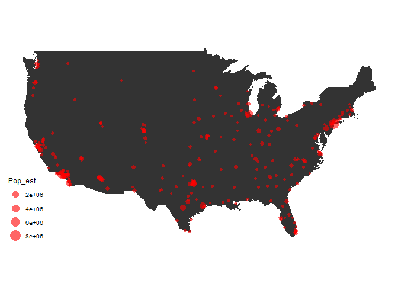

```r
ggplot(usa, aes(x = long, y = lat, group = group)) +
  geom_polygon() +
  geom_point(data = cities, aes(group = State, size = Pop_est),
             col = "red", shape = 16, alpha = 0.6) +
  coord_map() +
  theme_map()
```

```r
# Arrange cities
library(dplyr)
cities_arr <- arrange(cities, Pop_est)

cities_arr %>%
  head() %>%
  kable() %>%
  kable_styling(bootstrap_options = c("striped", "hover", "condensed"))
```

| City | State | Pop_est | lat | long |
| --- | --- | --- | --- | --- |
| Renton | Washington | 100242 | 47.4867 | -122.1953 |
| Jurupa Valley | California | 100314 | 33.0011 | -117.4706 |
| San Angelo | Texas | 100450 | 31.4500 | -100.4500 |
| Davie | Florida | 100882 | 26.0814 | -80.2803 |
| Greeley | Colorado | 100883 | 40.4167 | -104.7167 |
| Vista | California | 100890 | 33.1936 | -117.2411 |

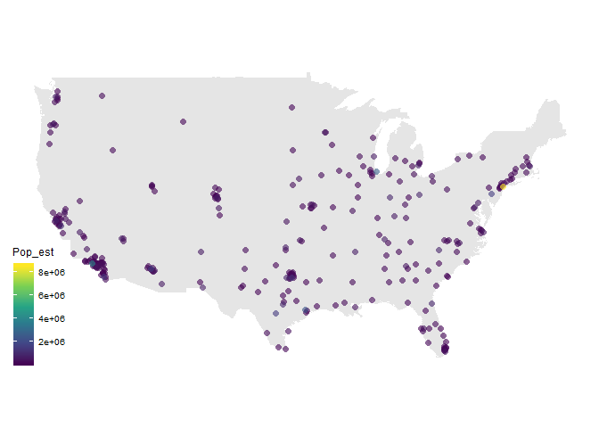

```r
# Copy-paste plot 1 and adapt
ggplot(usa, aes(x = long, y = lat, group = group)) +
  geom_polygon(fill = "grey90") +
  geom_point(data = cities_arr, aes(group = State, col = Pop_est),
             shape = 16, alpha = 0.6, size = 2) +
  coord_map() +
  theme_map() +
  scale_color_viridis_c()
```

Great! New York appears as a bright yellow anomly in a sea of darker points. If you didn’t set the order of the data, this point would have been obscured. You can also see LA, Chicago and Houston as lighter blue points.